# Actividad 2.6 Análisis discriminante

Rey Iván De La Fuente Chávez

2026-08-30

## 1. Preparación de los datos

El objetivo del análisis es clasificar las viviendas de acuerdo con su nivel de calidad de construcción mediante un análisis discriminante lineal (LDA).

La variable `grade` representa la calidad de construcción de la vivienda. Para utilizarla como variable categórica dependiente se agrupa en tres niveles:

- **Baja:** `grade <= 6`
- **Media:** `grade` entre 7 y 8
- **Alta:** `grade >= 9`

Esta agrupación permite trabajar con categorías suficientemente representadas y facilita la interpretación del modelo.

```r
library(ggplot2)
library(MASS)
library(MVN)
library(biotools)

# Cargar la base de datos
datos <- read.csv('C:\\Users\\reyiv\\Downloads\\kc_house_data-1.csv')

# Dimensiones de la base
dim(datos)
```

```
## [1] 21613    21
```

```r
# Primeras observaciones
head(datos)
```

```
##           id            date   price bedrooms bathrooms sqft_living sqft_lot
## 1 7129300520 20141013T000000  221900        3      1.00        1180     5650
## 2 6414100192 20141209T000000  538000        3      2.25        2570     7242
## 3 5631500400 20150225T000000  180000        2      1.00         770    10000
## 4 2487200875 20141209T000000  604000        4      3.00        1960     5000
## 5 1954400510 20150218T000000  510000        3      2.00        1680     8080
## 6 7237550310 20140512T000000 1225000        4      4.50        5420   101930
##   floors waterfront view condition grade sqft_above sqft_basement yr_built
## 1      1          0    0         3     7       1180             0     1955
## 2      2          0    0         3     7       2170           400     1951
## 3      1          0    0         3     6        770             0     1933
## 4      1          0    0         5     7       1050           910     1965
## 5      1          0    0         3     8       1680             0     1987
## 6      1          0    0         3    11       3890          1530     2001
##   yr_renovated zipcode     lat     long sqft_living15 sqft_lot15
## 1            0   98178 47.5112 -122.257          1340       5650
## 2         1991   98125 47.7210 -122.319          1690       7639
## 3            0   98028 47.7379 -122.233          2720       8062
## 4            0   98136 47.5208 -122.393          1360       5000
## 5            0   98074 47.6168 -122.045          1800       7503
## 6            0   98053 47.6561 -122.005          4760     101930
```

```r
# Estructura de las variables
str(datos)
```

```
## 'data.frame':    21613 obs. of  21 variables:
##  $ id           : num  7.13e+09 6.41e+09 5.63e+09 2.49e+09 1.95e+09 ...
##  $ date         : chr  "20141013T000000" "20141209T000000" "20150225T000000" "20141209T000000" ...
##  $ price        : num  221900 538000 180000 604000 510000 ...
##  $ bedrooms     : int  3 3 2 4 3 4 3 3 3 3 ...
##  $ bathrooms    : num  1 2.25 1 3 2 4.5 2.25 1.5 1 2.5 ...
##  $ sqft_living  : int  1180 2570 770 1960 1680 5420 1715 1060 1780 1890 ...
##  $ sqft_lot     : int  5650 7242 10000 5000 8080 101930 6819 9711 7470 6560 ...
##  $ floors       : num  1 2 1 1 1 1 2 1 1 2 ...
##  $ waterfront   : int  0 0 0 0 0 0 0 0 0 0 ...
##  $ view         : int  0 0 0 0 0 0 0 0 0 0 ...
##  $ condition    : int  3 3 3 5 3 3 3 3 3 3 ...
##  $ grade        : int  7 7 6 7 8 11 7 7 7 7 ...
##  $ sqft_above   : int  1180 2170 770 1050 1680 3890 1715 1060 1050 1890 ...
##  $ sqft_basement: int  0 400 0 910 0 1530 0 0 730 0 ...
##  $ yr_built     : int  1955 1951 1933 1965 1987 2001 1995 1963 1960 2003 ...
##  $ yr_renovated : int  0 1991 0 0 0 0 0 0 0 0 ...
##  $ zipcode      : int  98178 98125 98028 98136 98074 98053 98003 98198 98146 98038 ...
##  $ lat          : num  47.5 47.7 47.7 47.5 47.6 ...
##  $ long         : num  -122 -122 -122 -122 -122 ...
##  $ sqft_living15: int  1340 1690 2720 1360 1800 4760 2238 1650 1780 2390 ...
##  $ sqft_lot15   : int  5650 7639 8062 5000 7503 101930 6819 9711 8113 7570 ...
```

La base contiene 21 variables relacionadas con características físicas, ubicación, precio y calidad de las viviendas.

## 2. Definición de la variable dependiente

Se crea la variable categórica `grade_cat` a partir de `grade`.

```r
datos$grade_cat <- cut(
  datos$grade,
  breaks = c(-Inf, 6, 8, Inf),
  labels = c("Baja", "Media", "Alta")
)

datos$grade_cat <- factor(
  datos$grade_cat,
  levels = c("Baja", "Media", "Alta")
)

# Distribución en la base completa
table(datos$grade_cat)
```

```
##
##  Baja Media  Alta
##  2313 15049  4251
```

```r
# Proporciones
round(prop.table(table(datos$grade_cat)), 4)
```

```
##
##   Baja  Media   Alta
## 0.1070 0.6963 0.1967
```

La variable `grade` original no se utilizará como predictora, ya que `grade_cat` fue construida directamente a partir de ella y hacerlo produciría fuga de información.

## 3. Selección de variables predictoras

Se seleccionan variables numéricas que describen características de las viviendas.

Se excluyen identificadores como `id` y `zipcode`, la fecha, la variable `grade` utilizada para crear la respuesta y variables categóricas codificadas con números como `waterfront`, `view` y `condition`.

También se evita utilizar simultáneamente `sqft_above`, `sqft_basement` y `sqft_living`, debido a que existe una relación directa entre estas medidas.

```r
predictores <- c(
  "price",
  "bedrooms",
  "bathrooms",
  "sqft_living",
  "sqft_lot",
  "floors",
  "sqft_basement",
  "yr_built",
  "lat",
  "long",
  "sqft_living15",
  "sqft_lot15"
)

predictores
```

```
##  [1] "price"         "bedrooms"      "bathrooms"     "sqft_living"
##  [5] "sqft_lot"      "floors"        "sqft_basement" "yr_built"
##  [9] "lat"           "long"          "sqft_living15" "sqft_lot15"
```

## 4. Muestreo aleatorio de 300 observaciones

De acuerdo con las instrucciones, se selecciona una muestra aleatoria de 300 observaciones.

Se utiliza una semilla para que el muestreo pueda reproducirse y obtener los mismos resultados cada vez que se ejecute el documento.

```r
# Conservar únicamente casos completos
datos_modelo <- datos[
  complete.cases(datos[, c(predictores, "grade_cat")]),
]

# Semilla reproducible
set.seed(123)

# Seleccionar 300 observaciones
indices <- sample(
  1:nrow(datos_modelo),
  size = 300,
  replace = FALSE
)

muestra <- datos_modelo[indices, ]

# Verificar tamaño
dim(muestra)
```

```
## [1] 300  22
```

```r
# Distribución de categorías
table(muestra$grade_cat)
```

```
##
##  Baja Media  Alta
##    27   216    57
```

### Interpretación

La muestra contiene 27 viviendas de calidad baja, 216 de calidad media y 57 de calidad alta. La categoría media representa la mayoría de las observaciones, por lo que existe cierto desbalance entre las clases.

# 5. Segmentación original de los datos

Antes de construir el modelo se busca identificar qué variables presentan mayores diferencias entre los tres grupos.

Para ello se calcula el estadístico F de un ANOVA para cada predictor. Un valor F más grande indica una mayor diferencia entre las medias de los grupos.

```r
f_valores <- sapply(
  predictores,
  function(variable) {

    modelo_anova <- aov(
      muestra[[variable]] ~ muestra$grade_cat
    )

    summary(modelo_anova)[[1]][["F value"]][1]
  }
)

ranking_discriminacion <- data.frame(
  Variable = names(f_valores),
  F = as.numeric(f_valores)
)

ranking_discriminacion <- ranking_discriminacion[
  order(ranking_discriminacion$F, decreasing = TRUE),
]

rownames(ranking_discriminacion) <- NULL

ranking_discriminacion
```

```
##         Variable          F
## 1    sqft_living 123.836381
## 2      bathrooms  85.531179
## 3  sqft_living15  83.958594
## 4          price  55.122041
## 5       bedrooms  39.372591
## 6         floors  27.068481
## 7       yr_built  20.342528
## 8            lat   3.877521
## 9  sqft_basement   3.295477
## 10          long   2.123702
## 11      sqft_lot   1.856481
## 12    sqft_lot15   1.435523
```

### Interpretación

Las variables que mejor separan inicialmente los grupos son `sqft_living`, `bathrooms` y `sqft_living15`. En particular, `sqft_living` presenta el mayor estadístico F, por lo que es la variable con mayores diferencias entre las categorías.

## 5.1 Gráfico de la segmentación original

Se utilizan las dos variables con mayor estadístico F para observar la separación de los grupos.

```r
var1 <- ranking_discriminacion$Variable[1]
var2 <- ranking_discriminacion$Variable[2]

var1
```

```
## [1] "sqft_living"
```

```r
var2
```

```
## [1] "bathrooms"
```

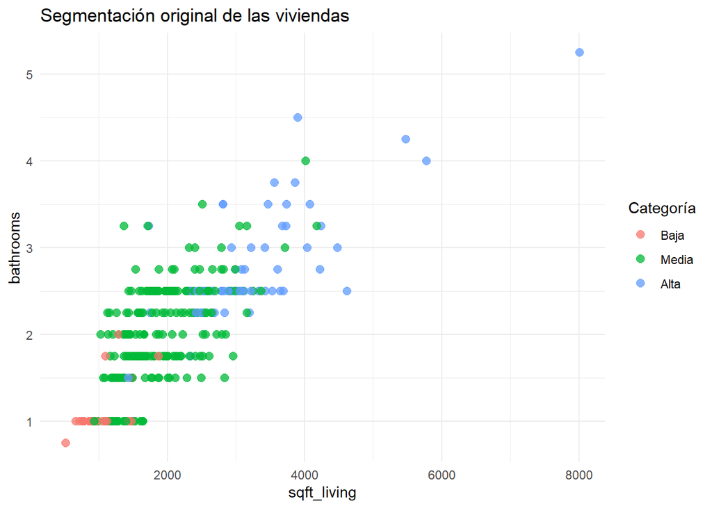

```r
ggplot(
  muestra,
  aes(
    x = .data[[var1]],
    y = .data[[var2]],
    color = grade_cat
  )
) +
  geom_point(
    alpha = 0.75,
    size = 2.5
  ) +
  labs(
    title = "Segmentación original de las viviendas",
    x = var1,
    y = var2,
    color = "Categoría"
  ) +
  theme_minimal()
```

### Interpretación

Las viviendas de calidad baja tienden a presentar menor superficie habitable y menos baños, mientras que las de calidad alta se concentran en valores mayores. Sin embargo, existe traslape entre los grupos, principalmente en la categoría media.

# 6. Análisis discriminante lineal

## 6.1 Medias de las variables predictoras por grupo

Se calcula la media de cada predictor dentro de cada categoría utilizando `tapply()`.

```r
medias_por_grupo <- sapply(
  predictores,
  function(variable) {

    tapply(
      muestra[[variable]],
      muestra$grade_cat,
      mean
    )
  }
)

medias_por_grupo <- round(
  medias_por_grupo,
  2
)

medias_por_grupo
```

```
##          price bedrooms bathrooms sqft_living sqft_lot floors sqft_basement
## Baja  265509.3     2.52      1.14     1069.63  7362.74   1.09         90.37
## Media 459218.1     3.40      2.02     1912.19 12406.80   1.44        287.25
## Alta  961218.3     4.16      2.83     3277.21 18982.04   1.87        346.49
##       yr_built   lat    long sqft_living15 sqft_lot15
## Baja   1946.30 47.48 -122.26       1364.07    7564.93
## Media  1970.71 47.56 -122.22       1863.18   11091.14
## Alta   1985.47 47.56 -122.20       2748.32   16742.14
```

### Interpretación

En general, las viviendas de calidad alta presentan mayores valores de precio, habitaciones, baños y superficie habitable. Por ejemplo, la superficie habitable promedio aumenta de aproximadamente 1,070 pies cuadrados en el grupo bajo a 3,277 en el grupo alto.

## 6.2 Probabilidades a priori

Las probabilidades a priori representan la probabilidad inicial de pertenecer a cada grupo antes de considerar los predictores.

Se calculan mediante:

$$P(G_k)=\frac{n_k}{n}$$

donde $n_k$ es el número de observaciones del grupo y $n$ es el tamaño total de la muestra.

```r
# Frecuencias
frecuencias <- table(
  muestra$grade_cat
)

frecuencias
```

```
##
##  Baja Media  Alta
##    27   216    57
```

```r
# Probabilidades a priori
probabilidades_priori <- prop.table(
  table(muestra$grade_cat)
)

round(
  probabilidades_priori,
  4
)
```

```
##
##  Baja Media  Alta
##  0.09  0.72  0.19
```

### Interpretación

Las probabilidades a priori son 0.09 para calidad baja, 0.72 para media y 0.19 para alta. Por lo tanto, antes de utilizar los predictores, una vivienda de la muestra tiene mayor probabilidad de pertenecer a la categoría media.

# 7. Construcción del modelo LDA

El análisis discriminante lineal busca construir combinaciones lineales de los predictores que permitan separar lo mejor posible los grupos.

La forma general de una función discriminante es:

$$LD_k =
a_1X_1+a_2X_2+\cdots+a_pX_p$$

donde los coeficientes $a_i$ son determinados por el modelo.

```r
# Construir fórmula
formula_lda <- as.formula(
  paste(
    "grade_cat ~",
    paste(
      predictores,
      collapse = " + "
    )
  )
)

formula_lda
```

```
## grade_cat ~ price + bedrooms + bathrooms + sqft_living + sqft_lot +
##     floors + sqft_basement + yr_built + lat + long + sqft_living15 +
##     sqft_lot15
```

```r
# Ajustar modelo
modelo_lda <- MASS::lda(
  formula_lda,
  data = muestra
)

modelo_lda
```

```
## Call:
## lda(formula_lda, data = muestra)
##
## Prior probabilities of groups:
##  Baja Media  Alta
##  0.09  0.72  0.19
##
## Group means:
##          price bedrooms bathrooms sqft_living  sqft_lot   floors sqft_basement
## Baja  265509.3 2.518519  1.138889    1069.630  7362.741 1.092593      90.37037
## Media 459218.1 3.398148  2.019676    1912.190 12406.801 1.444444     287.25000
## Alta  961218.3 4.157895  2.828947    3277.211 18982.035 1.868421     346.49123
##       yr_built      lat      long sqft_living15 sqft_lot15
## Baja  1946.296 47.48141 -122.2599      1364.074   7564.926
## Media 1970.708 47.55696 -122.2200      1863.181  11091.139
## Alta  1985.474 47.56409 -122.2007      2748.316  16742.140
##
## Coefficients of linear discriminants:
##                         LD1           LD2
## price          4.708862e-07  1.328761e-06
## bedrooms       1.447684e-01 -4.639253e-01
## bathrooms      3.440315e-01 -8.206522e-01
## sqft_living    8.324475e-04  8.218047e-04
## sqft_lot       1.404948e-06 -7.988659e-06
## floors         6.060973e-02 -4.514563e-02
## sqft_basement -8.748286e-04 -1.172293e-03
## yr_built       5.777832e-03 -1.673874e-02
## lat            3.727188e-01 -4.231930e+00
## long          -2.299701e+00 -5.201049e-02
## sqft_living15  6.383147e-04  1.524598e-04
## sqft_lot15     1.595927e-06 -2.948159e-06
##
## Proportion of trace:
##    LD1    LD2
## 0.9054 0.0946
```

### Interpretación

Como existen tres grupos, el modelo genera dos funciones discriminantes: LD1 y LD2. La primera función explica aproximadamente 90.54% de la separación entre los grupos, mientras que LD2 explica el 9.46% restante. Por lo tanto, LD1 contiene la mayor parte de la información discriminante.

# 8. Funciones lineales discriminantes

El número máximo de funciones discriminantes es:

$$\min(p,g-1)$$

donde $p$ es el número de predictores y $g$ es el número de grupos.

En este caso:

$$g-1=3-1=2$$

por lo que se obtienen dos funciones: LD1 y LD2.

## 8.1 Coeficientes

```r
coeficientes_lda <- modelo_lda$scaling

coeficientes_lda
```

```
##                         LD1           LD2
## price          4.708862e-07  1.328761e-06
## bedrooms       1.447684e-01 -4.639253e-01
## bathrooms      3.440315e-01 -8.206522e-01
## sqft_living    8.324475e-04  8.218047e-04
## sqft_lot       1.404948e-06 -7.988659e-06
## floors         6.060973e-02 -4.514563e-02
## sqft_basement -8.748286e-04 -1.172293e-03
## yr_built       5.777832e-03 -1.673874e-02
## lat            3.727188e-01 -4.231930e+00
## long          -2.299701e+00 -5.201049e-02
## sqft_living15  6.383147e-04  1.524598e-04
## sqft_lot15     1.595927e-06 -2.948159e-06
```

## 8.2 Centro de las variables

Para obtener las funciones completas también se calcula el centro ponderado utilizado por el modelo.

```r
centro_lda <- colSums(
  modelo_lda$prior *
    modelo_lda$means
)

round(
  centro_lda,
  4
)
```

```
##         price      bedrooms     bathrooms   sqft_living      sqft_lot
##   537164.3567        3.4633        2.0942     2095.7133    13202.1300
##        floors sqft_basement      yr_built           lat          long
##        1.4933      280.7867     1971.3167       47.5515     -122.2199
## sqft_living15    sqft_lot15
##     1986.4367    11847.4700
```

Las funciones discriminantes pueden escribirse de manera centrada como:

$$LD_k =
a_1(X_1-\bar X_1)
+\cdots+
a_p(X_p-\bar X_p)$$

## 8.3 Escritura automática de LD1 y LD2

El siguiente código utiliza notación científica para evitar que coeficientes pequeños sean mostrados como cero.

```r
funciones_lda <- sapply(
  1:ncol(coeficientes_lda),
  function(k) {

    coef_k <- coeficientes_lda[, k]

    terminos <- paste0(
      format(
        coef_k,
        scientific = TRUE,
        digits = 6
      ),
      "*(",
      rownames(coeficientes_lda),
      " - ",
      round(
        centro_lda[
          rownames(coeficientes_lda)
        ],
        4
      ),
      ")"
    )

    paste0(
      colnames(coeficientes_lda)[k],
      " = ",
      paste(
        terminos,
        collapse = " + "
      )
    )
  }
)

cat(
  paste(
    funciones_lda,
    collapse = "\n\n"
  )
)
```

[output not shown]

### Interpretación

LD1 es la función más importante para distinguir las categorías, ya que concentra más del 90% de la capacidad discriminante. LD2 aporta una separación adicional mucho menor.

# 9. Valores discriminantes

Una vez construido el modelo se obtiene el valor de LD1 y LD2 de cada vivienda.

```r
predicciones <- predict(
  modelo_lda,
  newdata = muestra
)

head(
  predicciones$x
)
```

```
##              LD1        LD2
## 18847  0.3898937 -1.5824177
## 18895 -0.3515390 -0.5675715
## 2986   0.7202460  0.5433723
## 1842   2.4287296  1.0649402
## 3371   0.6757416  0.2108539
## 11638 -1.7716890  1.2392037
```

```r
scores_lda <- data.frame(
  Clase = muestra$grade_cat,
  predicciones$x
)

head(
  scores_lda
)
```

```
##       Clase        LD1        LD2
## 18847 Media  0.3898937 -1.5824177
## 18895 Media -0.3515390 -0.5675715
## 2986  Media  0.7202460  0.5433723
## 1842   Alta  2.4287296  1.0649402
## 3371  Media  0.6757416  0.2108539
## 11638  Baja -1.7716890  1.2392037
```

# 10. Histogramas de valores discriminantes

## 10.1 Histograma de LD1

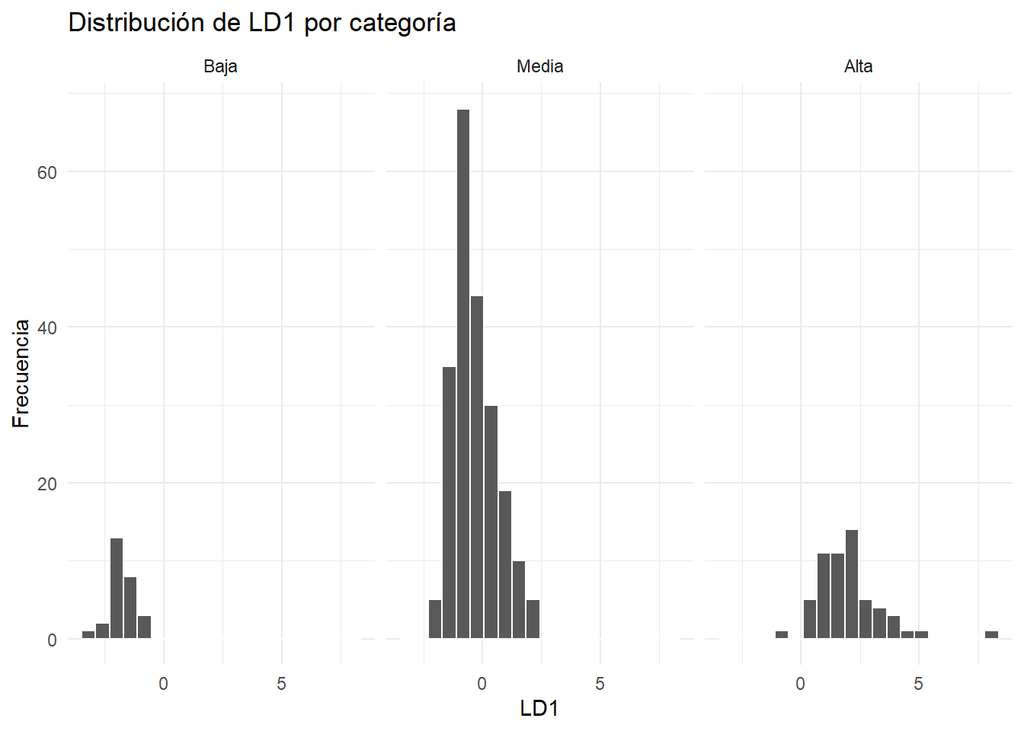

```r
ggplot(
  scores_lda,
  aes(x = LD1)
) +
  geom_histogram(
    bins = 20,
    color = "white"
  ) +
  facet_wrap(
    ~ Clase
  ) +
  labs(
    title = "Distribución de LD1 por categoría",
    x = "LD1",
    y = "Frecuencia"
  ) +
  theme_minimal()
```

### Interpretación

LD1 presenta una separación clara entre los extremos: las viviendas de calidad baja se concentran principalmente en valores negativos y las de calidad alta en valores positivos. La categoría media se encuentra entre ambas y presenta mayor traslape.

## 10.2 Histograma de LD2

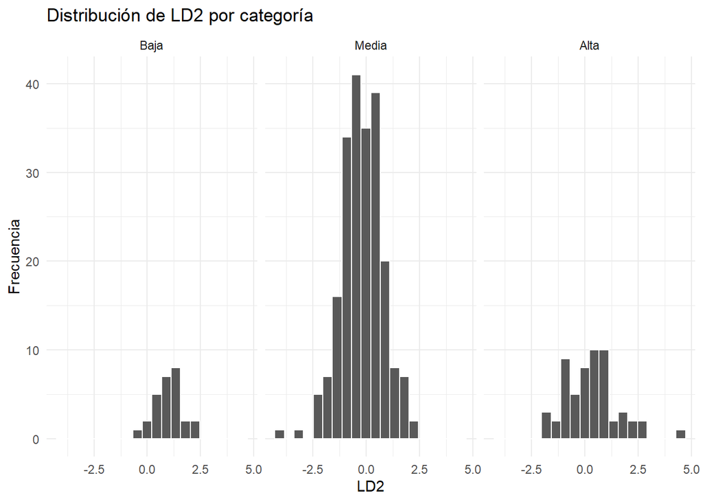

```r
ggplot(
  scores_lda,
  aes(x = LD2)
) +
  geom_histogram(
    bins = 20,
    color = "white"
  ) +
  facet_wrap(
    ~ Clase
  ) +
  labs(
    title = "Distribución de LD2 por categoría",
    x = "LD2",
    y = "Frecuencia"
  ) +
  theme_minimal()
```

### Interpretación

En LD2 existe un traslape considerable entre las tres categorías, por lo que esta segunda función discrimina menos que LD1. Esto coincide con su menor porcentaje de información discriminante.

# 11. Segmentación predicha por el modelo

Se obtiene la clasificación estimada por el modelo para cada vivienda.

```r
muestra$prediccion_lda <- predicciones$class

table(
  muestra$prediccion_lda
)
```

```
##
##  Baja Media  Alta
##    12   239    49
```

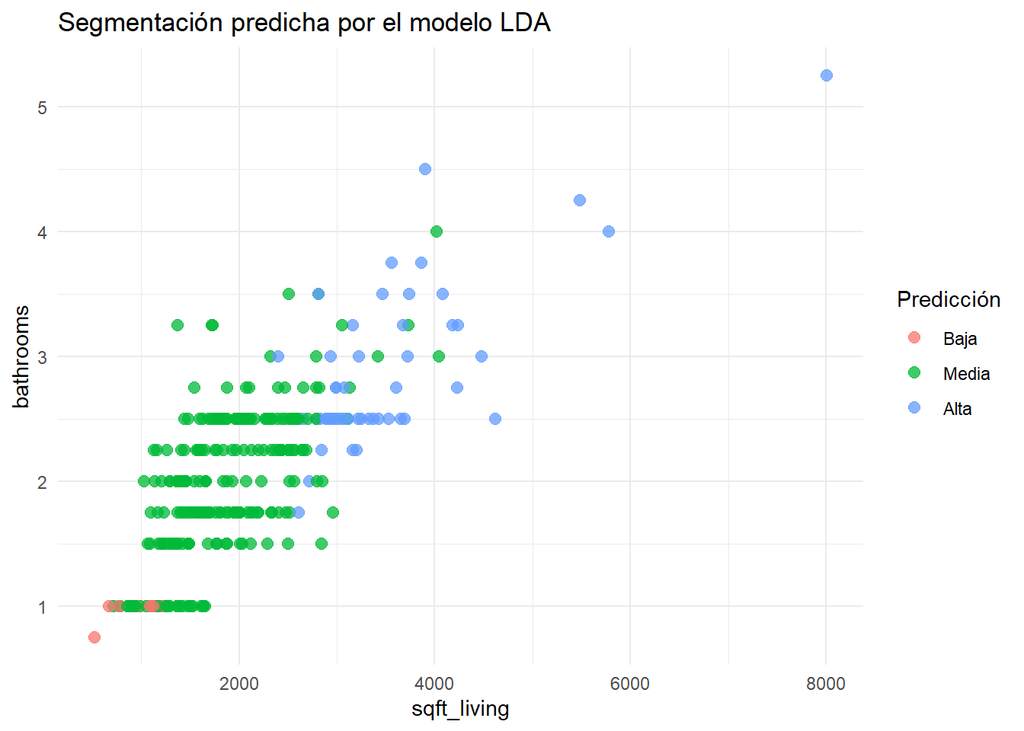

```r
ggplot(
  muestra,
  aes(
    x = .data[[var1]],
    y = .data[[var2]],
    color = prediccion_lda
  )
) +
  geom_point(
    alpha = 0.75,
    size = 2.5
  ) +
  labs(
    title = "Segmentación predicha por el modelo LDA",
    x = var1,
    y = var2,
    color = "Predicción"
  ) +
  theme_minimal()
```

### Interpretación

El modelo conserva el patrón general de los datos: valores pequeños de `sfqt_living` y `bathrooms` se relacionan con calidad baja y valores altos con calidad alta. Sin embargo, el modelo clasifica una gran cantidad de viviendas como calidad media.

# 12. Evaluación de la precisión del modelo

Para evaluar el poder predictivo se utiliza validación cruzada **Leave-One-Out (LOOCV)**.

En cada iteración se deja fuera una observación, el modelo se construye con las 299 restantes y después intenta clasificar la observación excluida. El proceso se repite para las 300 viviendas.

Este procedimiento ofrece una evaluación más realista que medir el desempeño con las mismas observaciones utilizadas para ajustar el modelo.

```r
modelo_cv <- MASS::lda(
  formula_lda,
  data = muestra,
  CV = TRUE
)

clase_real <- muestra$grade_cat

clase_predicha <- modelo_cv$class
```

## 12.1 Tabla de contingencia

Las filas corresponden a las clases reales y las columnas a las clases predichas. Los valores de la diagonal representan clasificaciones correctas.

```r
tabla_contingencia <- table(
  Real = clase_real,
  Predicha = clase_predicha
)

tabla_contingencia
```

```
##        Predicha
## Real    Baja Media Alta
##   Baja     8    19    0
##   Media    4   197   15
##   Alta     0    26   31
```

## 12.2 Precisión global

La precisión se calcula como:

$$Precisión =
\frac{\text{Predicciones correctas}}
{\text{Total de predicciones}}
\times 100$$

```r
precision <- mean(
  clase_real == clase_predicha
)

porcentaje_precision <- precision * 100

round(
  porcentaje_precision,
  2
)
```

```
## [1] 78.67
```

## 12.3 Porcentaje de error

$$Error = 100 - Precisión$$

```r
porcentaje_error <- (
  1 - precision
) * 100

round(
  porcentaje_error,
  2
)
```

```
## [1] 21.33
```

```r
cat(
  "Precisión:",
  round(porcentaje_precision, 2),
  "%\n"
)
```

```
## Precisión: 78.67 %
```

```r
cat(
  "Error:",
  round(porcentaje_error, 2),
  "%"
)
```

```
## Error: 21.33 %
```

## 12.4 Acierto por categoría

Debido a que los grupos no tienen el mismo tamaño, también es útil observar qué porcentaje de cada clase se clasificó correctamente.

```r
acierto_por_clase <- (
  diag(tabla_contingencia) /
    rowSums(tabla_contingencia)
) * 100

round(
  acierto_por_clase,
  2
)
```

```
##  Baja Media  Alta
## 29.63 91.20 54.39
```

### Interpretación

El modelo obtiene una precisión global de **78.67%** y un error de **21.33%**. Clasifica correctamente 197 de 216 viviendas de calidad media, pero solo 8 de 27 de calidad baja y 31 de 57 de calidad alta.

Por ello, el desempeño global es aceptable, pero el modelo funciona mucho mejor para la categoría media que para las demás. No puede considerarse un clasificador completamente sólido para las tres categorías.

# 13. Validación de supuestos

El análisis discriminante lineal supone principalmente:

1. Normalidad multivariada dentro de cada grupo.
2. Igualdad de las matrices de varianzas y covarianzas entre grupos.

## 13.1 Normalidad multivariada

Se utiliza la prueba de Mardia.

Las hipótesis son:

$$H_0:
\text{Los datos siguen una distribución normal multivariada}$$

$$H_1:
\text{Los datos no siguen una distribución normal multivariada}$$

Se utiliza un nivel de significancia de:

$$\alpha = 0.05$$

Si $p < 0.05$, se rechaza la hipótesis nula.

```r
resultados_normalidad <- list()

for (grupo in levels(muestra$grade_cat)) {

  datos_grupo <- muestra[
    muestra$grade_cat == grupo,
    predictores
  ]

  cat(
    "\n====================================\n"
  )

  cat(
    "Grupo:",
    grupo,
    "\n"
  )

  cat(
    "Número de observaciones:",
    nrow(datos_grupo),
    "\n"
  )

  cat(
    "====================================\n"
  )

  resultado <- MVN::mvn(
    data = datos_grupo,
    mvn_test = "mardia"
  )

  resultados_normalidad[[grupo]] <- resultado

  print(
    resultado$multivariate_normality
  )
}
```

```
##
## ====================================
## Grupo: Baja
## Número de observaciones: 27
## ====================================
##              Test Statistic p.value     Method          MVN
## 1 Mardia Skewness   453.317  <0.001 asymptotic ✗ Not normal
## 2 Mardia Kurtosis     1.133   0.257 asymptotic     ✓ Normal
##
## ====================================
## Grupo: Media
## Número de observaciones: 216
## ====================================
##              Test Statistic p.value     Method          MVN
## 1 Mardia Skewness 11582.686  <0.001 asymptotic ✗ Not normal
## 2 Mardia Kurtosis   125.002  <0.001 asymptotic ✗ Not normal
##
## ====================================
## Grupo: Alta
## Número de observaciones: 57
## ====================================
##              Test Statistic p.value     Method          MVN
## 1 Mardia Skewness  1211.330  <0.001 asymptotic ✗ Not normal
## 2 Mardia Kurtosis    14.052  <0.001 asymptotic ✗ Not normal
```

### Interpretación

La prueba de Mardia detecta falta de normalidad en los tres grupos. En calidad baja se rechaza la normalidad por asimetría, mientras que en los grupos media y alta tanto la asimetría como la curtosis presentan valores p menores a 0.05.

Por lo tanto, **no se cumple el supuesto de normalidad multivariada**.

# 14. Homogeneidad de matrices de covarianzas

Para comprobar si los grupos presentan matrices de covarianzas semejantes se utiliza la prueba M de Box.

Las hipótesis son:

$$H_0:
\Sigma_{Baja}
=
\Sigma_{Media}
=
\Sigma_{Alta}$$

$$H_1:
\text{Al menos una matriz de covarianzas es diferente}$$

Si $p < 0.05$, se rechaza la igualdad de matrices de covarianzas.

```r
X <- muestra[
  ,
  predictores
]

resultado_boxm <- biotools::boxM(
  X,
  muestra$grade_cat
)

resultado_boxm
```

```
##
##  Box's M-test for Homogeneity of Covariance Matrices
##
## data:  X
## Chi-Sq (approx.) = 800.44, df = 156, p-value < 2.2e-16
```

### Interpretación

La prueba M de Box obtiene un valor p menor a 0.05, por lo que se rechaza la hipótesis de igualdad de matrices de covarianzas.

Por lo tanto, **no se cumple el supuesto de homogeneidad de las matrices de covarianzas**.

# 15. Conclusiones

El análisis muestra que las características que más ayudan a distinguir la calidad de las viviendas son principalmente la superficie habitable (`sqft_living`), el número de baños y la superficie habitable de viviendas cercanas (`sqft_living15`).

El modelo LDA alcanza una precisión de **78.67%**, con un error de **21.33%**. Su mejor desempeño ocurre en viviendas de calidad media, mientras que presenta más dificultades para identificar las categorías baja y alta.

Además, las pruebas de Mardia y M de Box muestran que no se cumplen los supuestos de normalidad multivariada ni de igualdad de matrices de covarianzas. Por esta razón, aunque el modelo logra una clasificación razonable, sus resultados deben interpretarse con precaución.